# Dataiku - Testing dataset

Xavier Prudent

November 18, 2016

## Retrieving the data file

```r
## Download the data
URL <- "http://thomasdata.s3.amazonaws.com/ds/us_census_full.zip"
DESTFILE <- "us_census_full.zip"
#download.file( url = URL, destfile = DESTFILE )
## Unzip the data file
#unzip( DESTFILE )
```

## Visualization of the data

The names and position of the columns have been extracted and checked by hand, even though that is feasible automatically.

```r
## Path to the learning dataset
LEARN.DATA <- "us_census_full/census_income_learn.csv"

## Replace question marks by NA, and remove white spaces
#system(paste("sed s/\'?\'/'NA'/g",LEARN.DATA,"> foo; mv foo", LEARN.DATA))
#system(paste("sed s/\' \'//g",LEARN.DATA,"> foo; mv foo", LEARN.DATA))

## Open the learning dataset
LEARN.DATA <- read.csv(LEARN.DATA, stringsAsFactors=FALSE)

## Extracting the names of the columns
HEADER <- read.table("header.txt")
colnames(LEARN.DATA) <- unlist(HEADER)

## Extracting the description of the each column
HEADER.DESCR <- read.table("column_description.txt")
HEADER.DESCR <- unlist(HEADER.DESCR)

## Create a dataframe for the variables characteristics
VAR.DF <- data.frame( HEADER, HEADER.DESCR)
colnames(VAR.DF) <- c("name","descr")

## Loop over each column
DATA.FRAC.MISS <- c()
DATA.CLASS <- c()
UNIQ.VAL.DAT <- c()
DATA.MEAN <- c()
DATA.SD <- c()
DATA.MIN <- c()
DATA.MAX <- c()
for( icol in 1:ncol(LEARN.DATA)){

  ## Extract the data for this column
  COL.DAT <- LEARN.DATA[,icol]

  ## Class of that data
  DATA.CLASS <- c(DATA.CLASS, class(COL.DAT) )

  ## Number of unique values
  UNIQ.VAL.DAT <- c( UNIQ.VAL.DAT, length(unique(COL.DAT)) )

  ## Fraction of missing values
  N.MISS <- length(which(is.na(COL.DAT)))
  FRAC.MISS <- 100*N.MISS / length(COL.DAT)
  DATA.FRAC.MISS <- c( DATA.FRAC.MISS, FRAC.MISS )

  ## Mean value and standard deviation, and min max
  if( DATA.CLASS != "character" ){
    DATA.MEAN <- c(DATA.MEAN, mean(COL.DAT,na.rm = TRUE))
    DATA.SD <- c( DATA.SD, sd(COL.DAT,na.rm = TRUE))
    DATA.MIN <- c( DATA.MIN, min(COL.DAT,na.rm = TRUE))
    DATA.MAX <- c( DATA.MAX, max(COL.DAT,na.rm = TRUE))
  } else{
     DATA.MEAN <- c(DATA.MEAN, NA)
    DATA.SD <- c( DATA.SD, NA)
DATA.MIN <- c(DATA.MIN, NA)
    DATA.MAX <- c( DATA.MAX, NA)
  }
}

## Add this info to the dataframe
VAR.DF$missInfo <- DATA.FRAC.MISS
VAR.DF$class <- DATA.CLASS
VAR.DF$uniqVal <- UNIQ.VAL.DAT
VAR.DF$mean <- DATA.MEAN
VAR.DF$sd <- DATA.SD
VAR.DF$min <- DATA.MIN
VAR.DF$max <- DATA.MAX
```

The following plot summarizes the class of the 42 columns, together with the fraction of missing data:

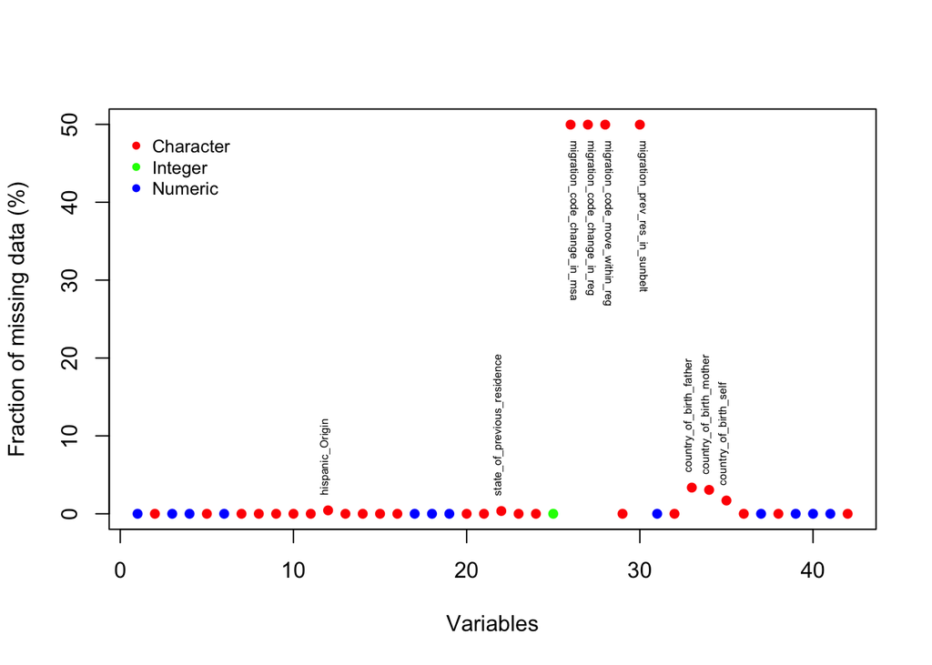

```r
plot(DATA.FRAC.MISS,col="white", xlab="Variables",ylab="Fraction of missing data (%)")
for( icol in 1:ncol(LEARN.DATA)){
if( DATA.CLASS[icol] == "character" ) DOT.COLOR <- "red"
else if( DATA.CLASS[icol] == "integer" ) DOT.COLOR <- "blue"
else if( DATA.CLASS[icol] == "numeric" ) DOT.COLOR <- "green"
else DOT.COLOR <- "black"
points(icol,DATA.FRAC.MISS[icol], pch=16, cex=1, col=DOT.COLOR)
if(DATA.FRAC.MISS[icol] > 0){
  if(DATA.FRAC.MISS[icol] > 40 ){
    agl <- -90
   y.offset <- -2
  }
else{
  agl <- 90
 y.offset <- 2
  }
  text(as.character(HEADER.DESCR[icol]),x=icol, y=DATA.FRAC.MISS[icol]+y.offset,cex=0.5, adj=c(0,0),srt=agl)
}
}
legend(x=0,y=50,col=c("red","green","blue"),pch=16,legend = c("Character","Integer","Numeric"),cex=0.8,bty="n")
```

Most missing data arise from the intra-USA migration variables, and to a lesser extent from the variables related to the extra-USA immigration (origin of the parents and place of birth).

Most variables are of character type, the ones with the most unique values are the geographical ones (migration intra-, extra-USA). There is probably enough segmentation so that non linear correlations can be seen.

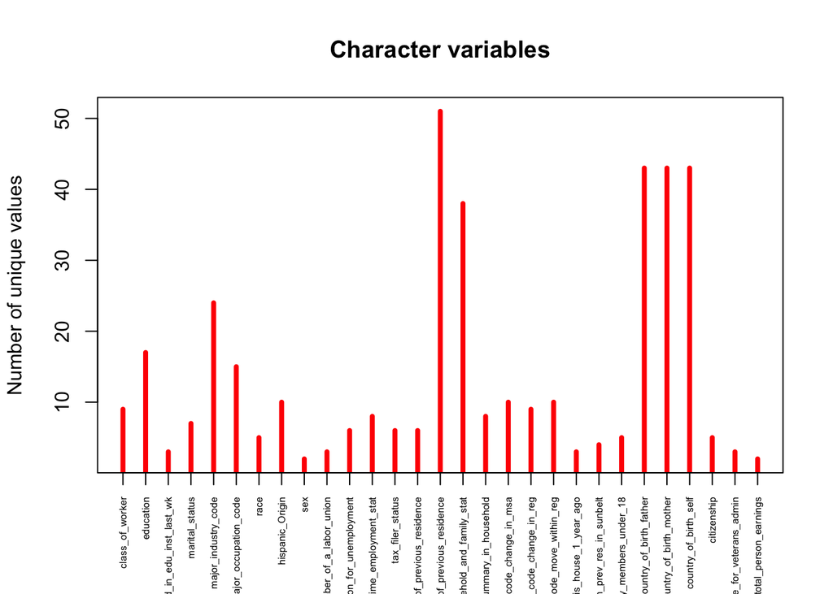

```r
## Consider only character variables
VAR.DF.CHAR <- subset(VAR.DF, class == "character")
## Plot the number of unique values
plot(VAR.DF.CHAR$uniqVal, type = "h", col="red", lwd=4, xlab="",ylab="Number of unique values",xaxt="n", main="Character variables")
axis(side=1,at=seq(from=1,to=nrow(VAR.DF.CHAR),by=1),labels = VAR.DF.CHAR$descr, las=2, cex.axis=0.5)
```

Let’s consider now the numerical variables (integer and float) :

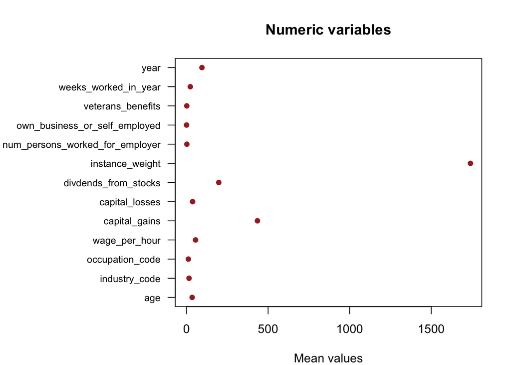

```r
## Consider only numeric variables
VAR.DF.NUM <- subset(VAR.DF, (class == "integer" | class == "numeric") )
## Plot the mean values
par(mar=c(4,12,4,2))
plot(c(1:nrow(VAR.DF.NUM))~VAR.DF.NUM$mean, ylab="",xlab="Mean values",main="Numeric variables", pch=16, col="brown",yaxt="n")
axis(side=2,at=1:nrow(VAR.DF.NUM),labels = VAR.DF.NUM$descr, las=2, cex.axis=0.8)
```

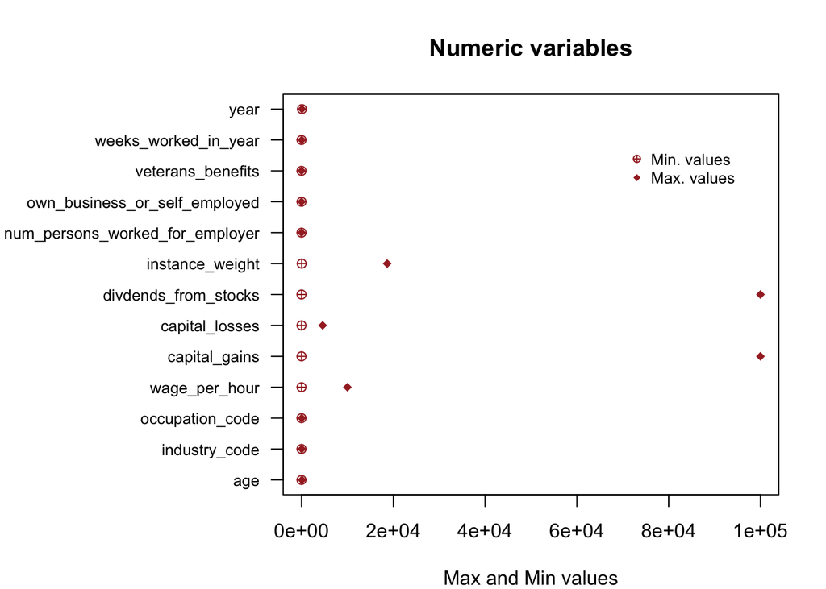

```r
## Plot the max and min values
par(mar=c(4,12,4,2))
plot(c(1:nrow(VAR.DF.NUM))~VAR.DF.NUM$max, ylab="",xlab="Max and Min values",main="Numeric variables", pch=18, col="brown",yaxt="n")
points(c(1:nrow(VAR.DF.NUM))~VAR.DF.NUM$min,pch=10, col="brown")
axis(side=2,at=1:nrow(VAR.DF.NUM),labels = VAR.DF.NUM$descr, las=2, cex.axis=0.8)
legend(x=7e4,y=12,col="brown",pch=c(10,18),legend = c("Min. values","Max. values"),cex=0.8,bty="n")
```

All numerical variables are positive, and go through highly different scales. Four variables in particular, counted in dollars, reach far higher values than the others. That will have to be carefully taken care of during the prediction stage.

Let’s plot now the distribution of all numerical variables (integers are in blue and the float ones are in green):

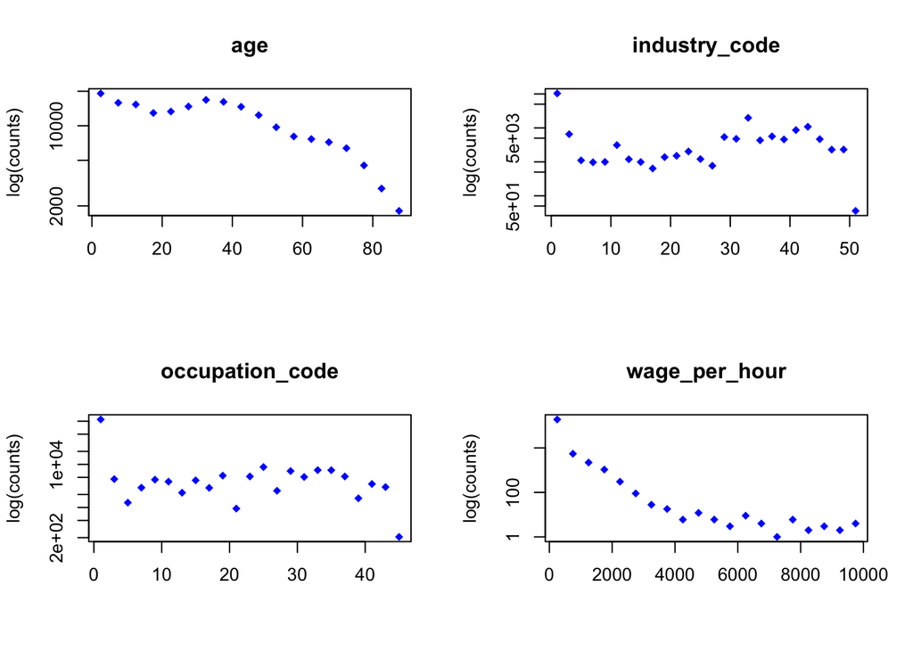

```r
## Consider only numeric variables
VAR.DF.NUM <- subset(VAR.DF, (class == "integer" | class == "numeric") )
## Extract the data
LEARN.DATA.NUM <- LEARN.DATA[,which(colnames(LEARN.DATA)%in% VAR.DF.NUM$name)]
## Plot a mosaic of distributions
plot.var <- function(start,end){
  if( start != end ) par(mfrow=c(2,2))
for( ivar in start:end){
  COL.DAT <- LEARN.DATA.NUM[,ivar]
  NAME <- VAR.DF.NUM$descr[ivar]
  CLASS <- VAR.DF.NUM$class[ivar]
  if( CLASS == "integer") COLOR <- "blue"
  if( CLASS == "numeric") COLOR <- "green"
    h <- hist(COL.DAT,plot=FALSE)
    plot(h$mids,h$counts,log="y",main=VAR.DF.NUM$descr[ivar], xlab="", pch=18, col=COLOR, ylab="log(counts)")
}
}
plot.var(1,4)
```

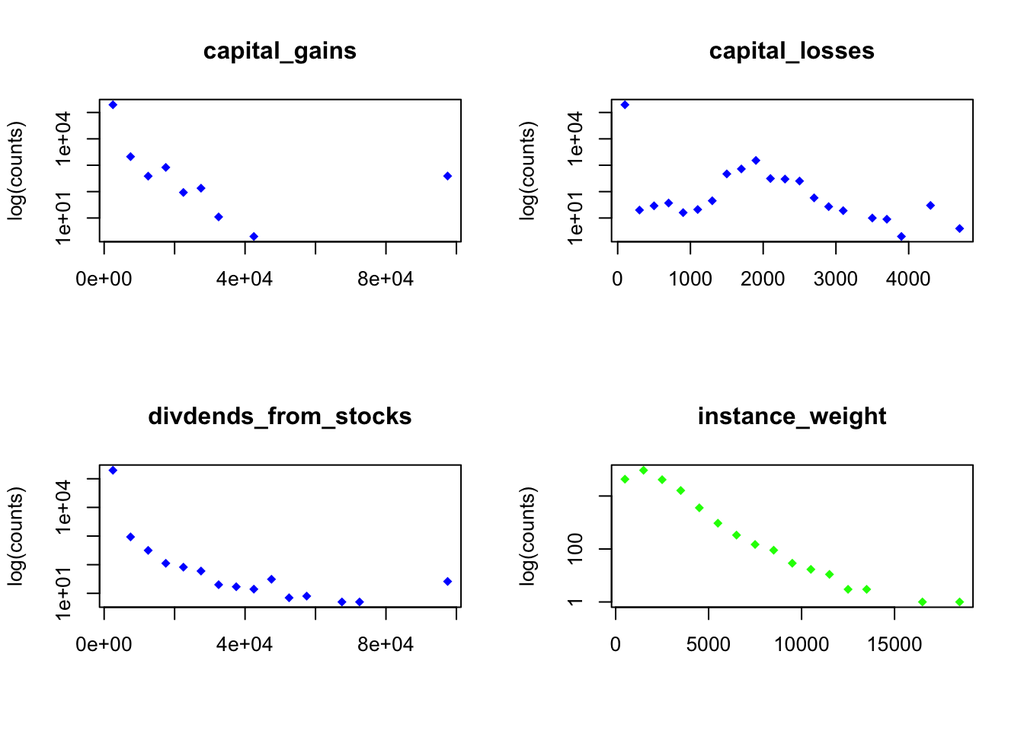

```r
plot.var(5,8)
```

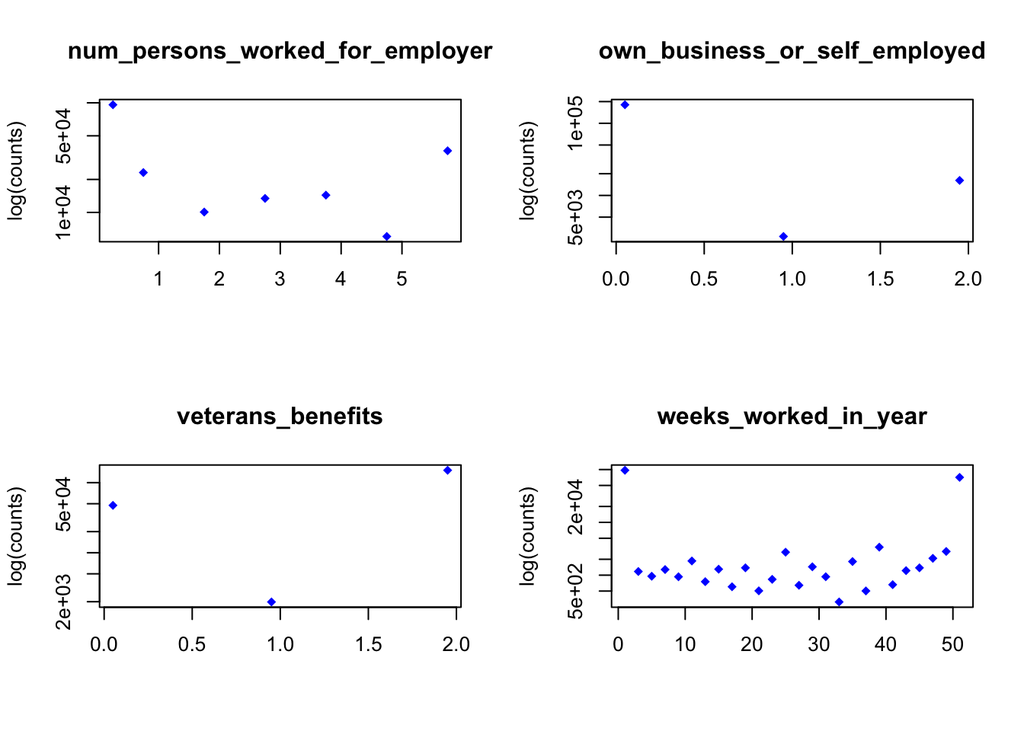

```r
plot.var(9,12)
```

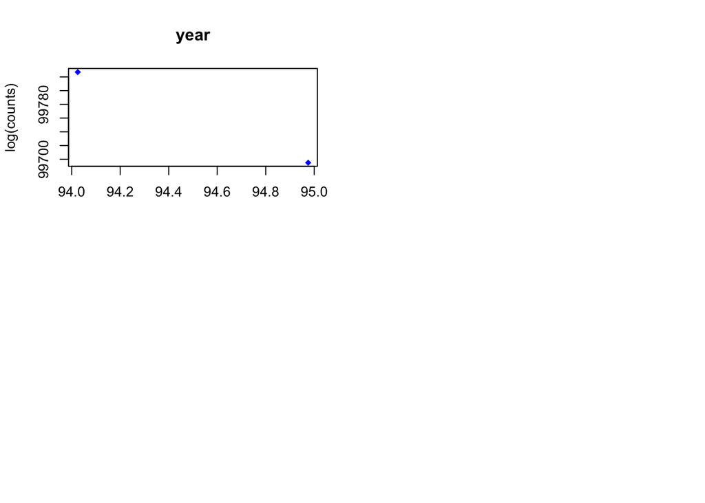

```r
plot.var(13,13)
```

The categorical variables are modified to be of numerical integer state:

```r
## Loop over all variables
for( icol in 1:ncol(LEARN.DATA) ){
  ## Consider categorical variables
if( DATA.CLASS[icol] != "character" ) next()
## List the unique values
    COL.DAT <- LEARN.DATA[,icol]
 UNIQ.VAL <- unique(COL.DAT)
  NB.UNIQ.VAL <- length(UNIQ.VAL)
  ## Replace their values by an integer
 for( ival in 1:NB.UNIQ.VAL){
   COL.DAT[COL.DAT==UNIQ.VAL[ival]] = ival
    LEARN.DATA[,icol] <- as.numeric(COL.DAT)
    DATA.MAX[icol] <- max(LEARN.DATA[,icol],na.rm = TRUE)
    DATA.MIN[icol] <- min(LEARN.DATA[,icol],na.rm = TRUE)
    DATA.MEAN[icol] <- mean(LEARN.DATA[,icol],na.rm = TRUE)
    DATA.SD[icol] <- sd(LEARN.DATA[,icol],na.rm = TRUE)
 }
}
  DATA.MAX <- as.numeric(DATA.MAX)
    DATA.MIN <- as.numeric(DATA.MIN)
    DATA.MEAN <- as.numeric(DATA.MEAN)
    DATA.SD <- as.numeric(DATA.SD)
```

## Scaling of the data

Because of the large differences in range between the variables, these are scaled to stay between 0 and 1 in order to improve further multi variable analysis. Only the response variable is kept raw.

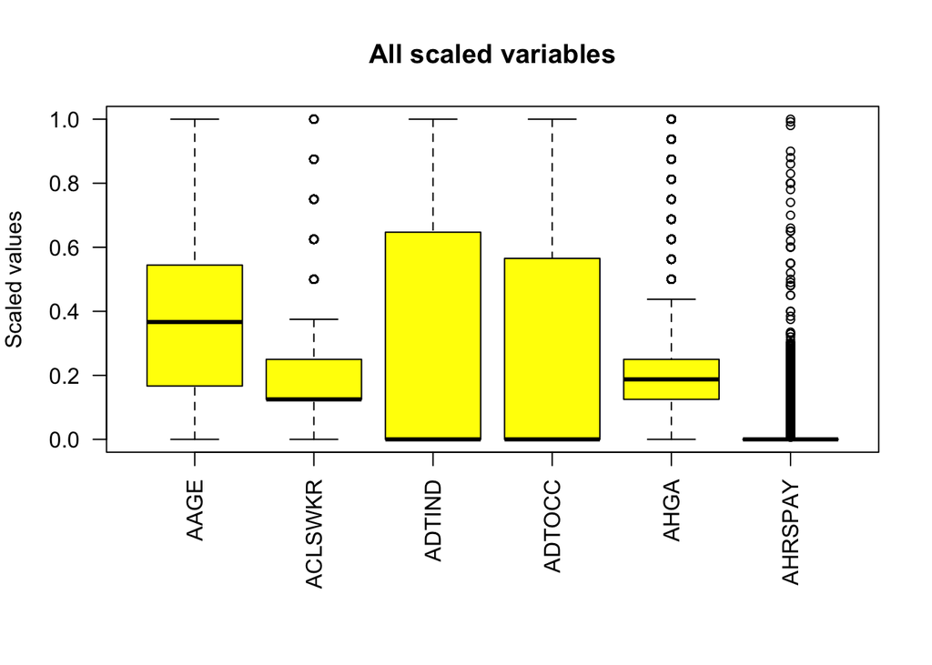

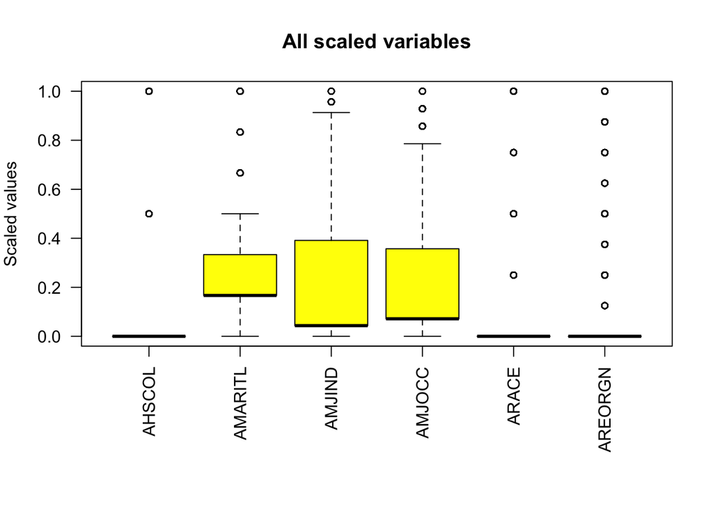

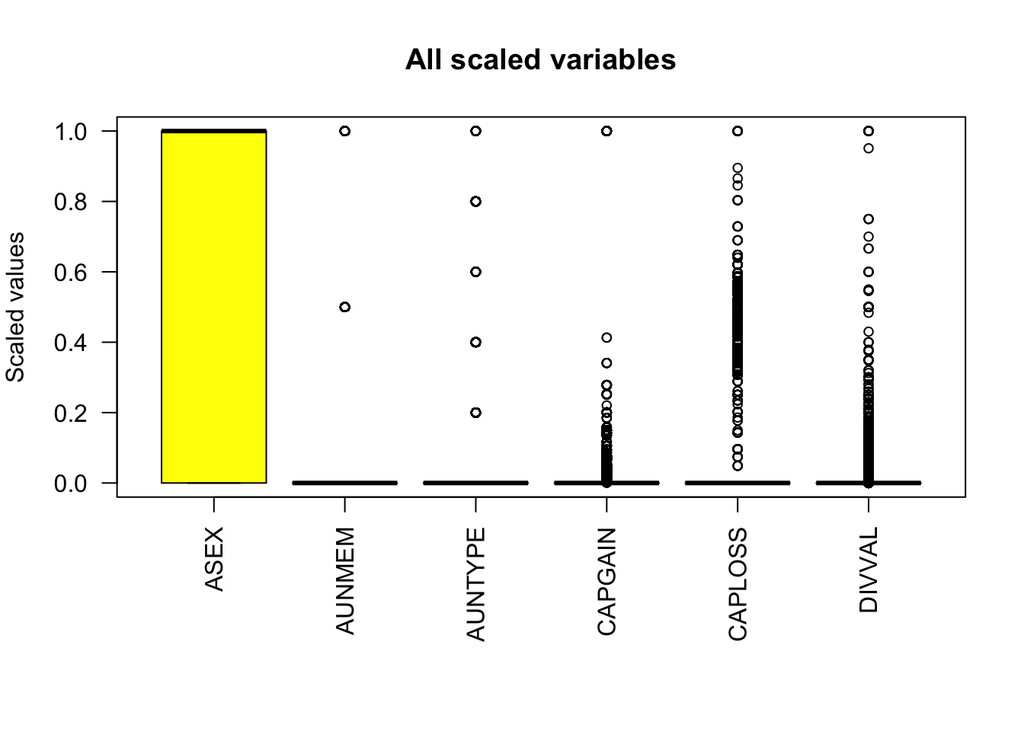

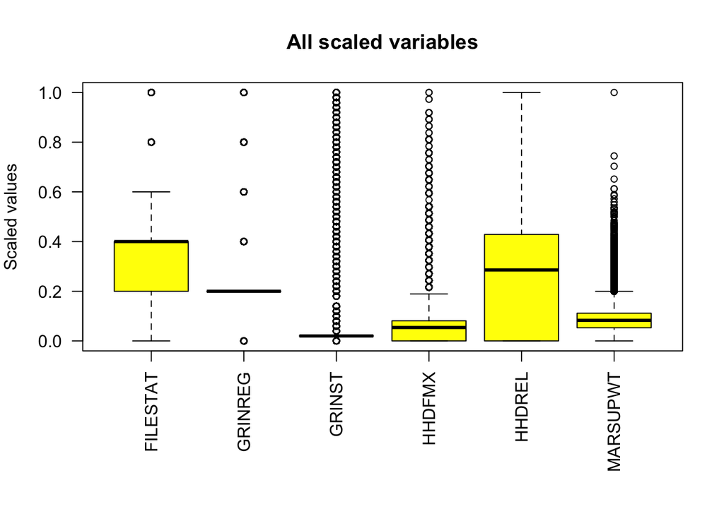

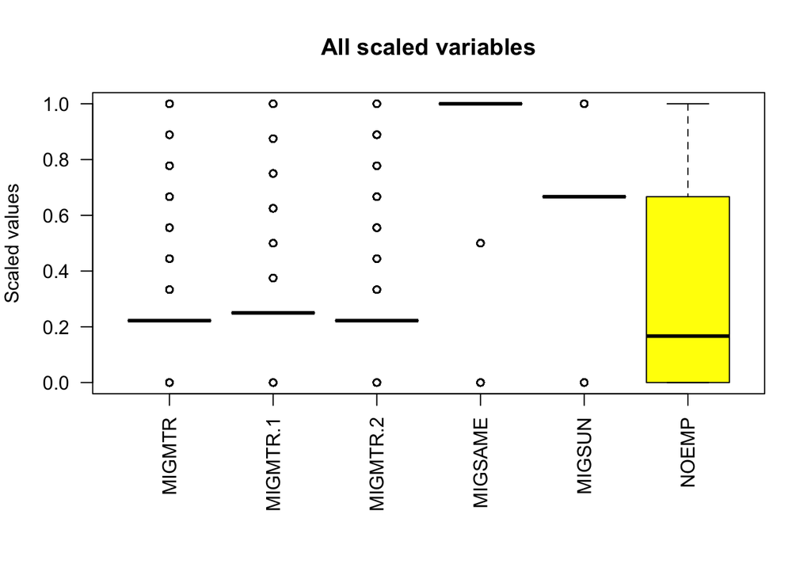

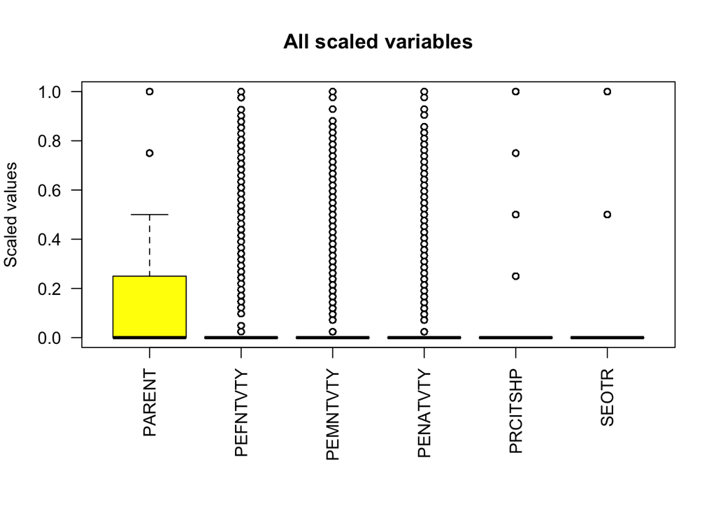

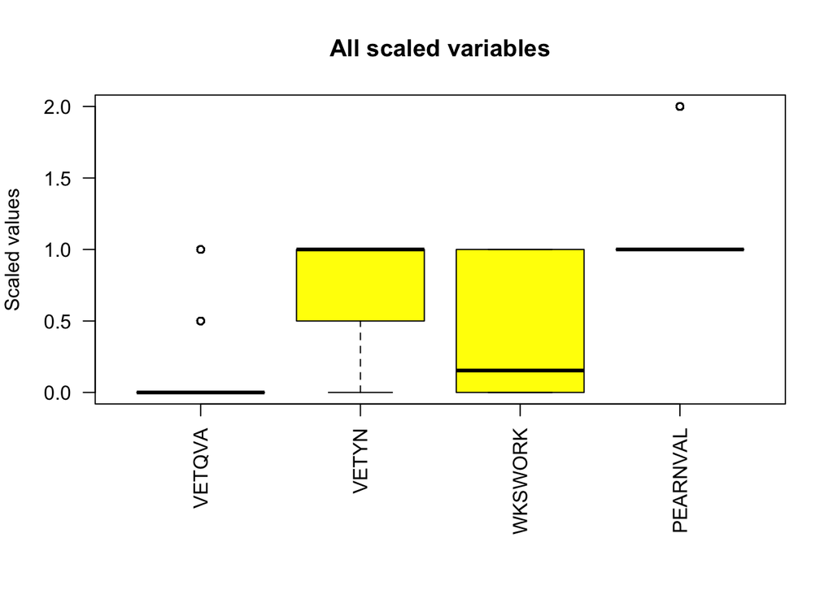

```r
## Remove all NA
 LEARN.DATA.SCALED <- na.omit(LEARN.DATA)
## Some variables are then constant, let's remove them
LEARN.DATA.SCALED <- LEARN.DATA.SCALED[,apply(LEARN.DATA.SCALED, 2, var, na.rm=TRUE) != 0]
## Loop over all variables
for( icol in 1:ncol(LEARN.DATA.SCALED) ){
  ## Keep the response raw
    if( colnames(LEARN.DATA.SCALED)[icol] == "PEARNVAL") next()
  ## Scale the predictor variables by doing X = (X - max(X) / (max(X)-min(X))
  MIN <- min(LEARN.DATA.SCALED[,icol])
  MAX <- max(LEARN.DATA.SCALED[,icol])
   LEARN.DATA.SCALED[,icol] <- (LEARN.DATA.SCALED[,icol] - MIN) / ( MAX - MIN )
}
## Let's check how they look like now
list.var <- 1:40
n.var <- 6
list.var <- split(list.var, ceiling(seq_along(list.var)/n.var))
for( i in 1:length(list.var)){
  list.var.plot <- as.vector(list.var[[i]])
par(mar=c(8,4,4,2))
boxplot(LEARN.DATA.SCALED[,list.var.plot], main="All scaled variables",xlab="",ylab="Scaled values",col="yellow",las=2,cex=0.8)
}
```

## 1st Dependency study: Principal Component Analysis

The goal is to predict the behavior of the 42th variable, a binary variable that says, whether an individual was able to save less or more than 50k dollars. Let’s first consider simple linear correlations between all variables using a principal component analysis:

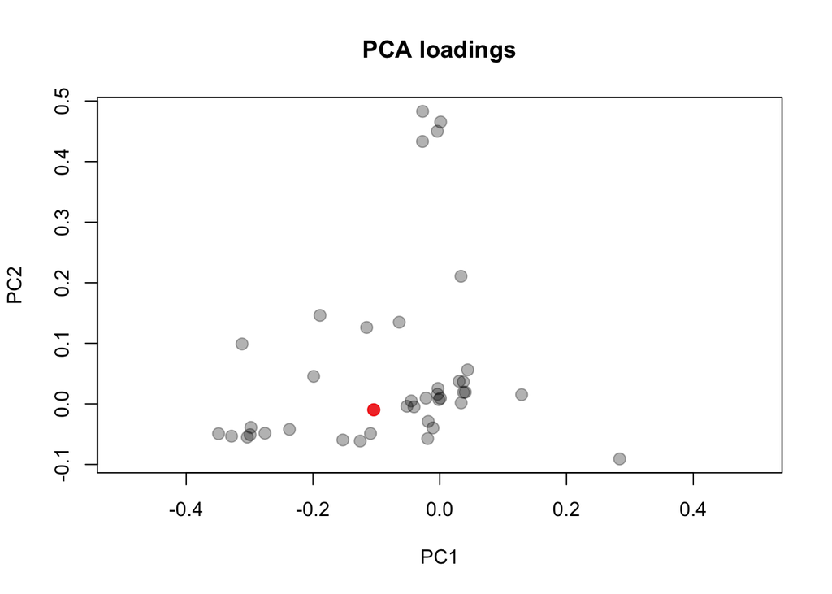

```r
## Run PCA with the correlation matrix
PCA <- princomp(LEARN.DATA.SCALED,cor=TRUE)
## Plot the loadings
LO=unclass(PCA$loadings)
plot(LO[,1],LO[,2], pch=20, cex=2, col=rgb(0,0,0,0.3), xlab="PC1", ylab="PC2",main="PCA loadings", xlim=c(-0.5,0.5))
## Plot the response variable
LO1.R <- LO["PEARNVAL",1]
LO2.R <- LO["PEARNVAL",2]
points( LO1.R, LO2.R, cex=2, pch=20, col=rgb(1,0,0,0.8))
```

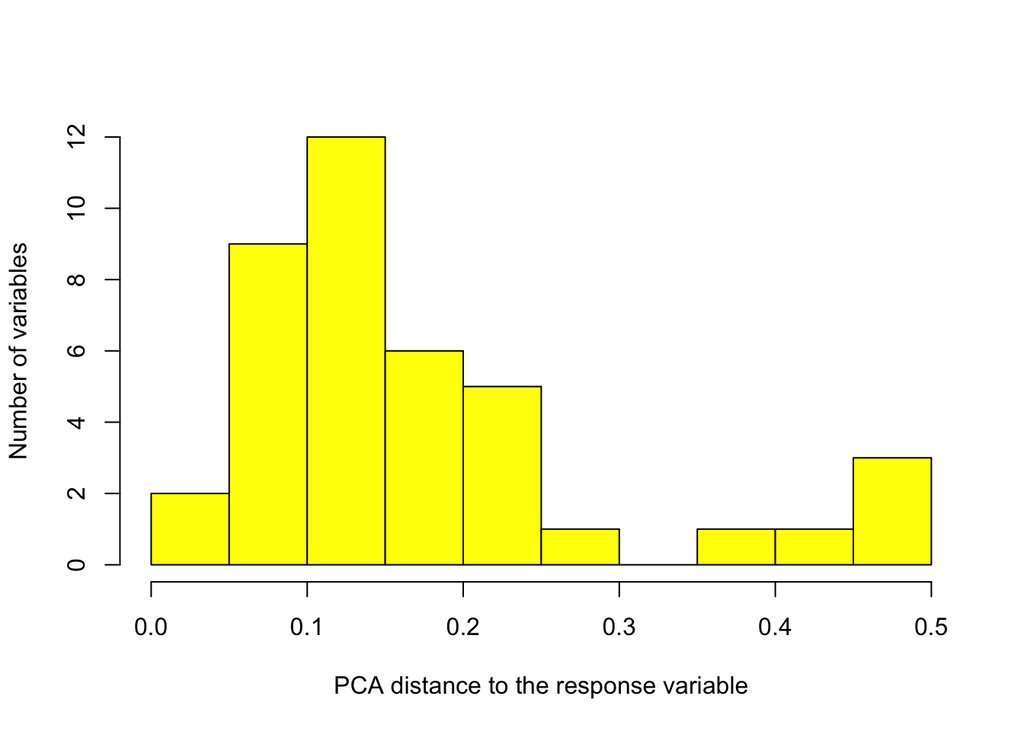

```r
## Distance to the response variable
DIST <- sqrt( (LO1.R-LO[,1])^2 + (LO2.R-LO[,2])^2)
hist(DIST,col="yellow",xlab="PCA distance to the response variable",ylab="Number of variables",main="",breaks=10)
```

```r
## What are the furthest variable away?
VAR.REM <- names(which(DIST>0.3))
print(VAR.REM)
```

```
## [1] "PARENT"   "PEFNTVTY" "PEMNTVTY" "PENATVTY" "PRCITSHP"
```

```r
## Remove uncorrelated variables
 LEARN.DATA <- LEARN.DATA[ , !(names(LEARN.DATA) %in% VAR.REM)]
## Remove all NA
 LEARN.DATA.SCALED <- na.omit(LEARN.DATA)
 ## Some variables are then constant, let's remove them
LEARN.DATA.SCALED <- LEARN.DATA.SCALED[,apply(LEARN.DATA.SCALED, 2, var, na.rm=TRUE) != 0]
## Loop over all variables
for( icol in 1:ncol(LEARN.DATA.SCALED) ){
  ## Keep the response raw
    if( colnames(LEARN.DATA.SCALED)[icol] == "PEARNVAL") next()
  ## Scale the predictor variables by doing X = (X - max(X) / (max(X)-min(X))
  MIN <- min(LEARN.DATA.SCALED[,icol])
  MAX <- max(LEARN.DATA.SCALED[,icol])
   LEARN.DATA.SCALED[,icol] <- (LEARN.DATA.SCALED[,icol] - MIN) / ( MAX - MIN )
}
```

After removing uncorrelated variables, the NA and the constant variables, 34+1 variables are left.

## Predictive methods: linear, NN and decision tree

We are going to apply different predictive learning tools. Given the large number of variables and statistics, a decision tree seems relevant, for the sake of comparison we will also use a linear model and a neural network:

Let’s start with a simple linear regression

```r
## Linear regression
PRED.LIN <- lm(PEARNVAL ~ ., data = LEARN.DATA.SCALED)
## Print the details
SUM.LIN <- summary(PRED.LIN)
print(SUM.LIN)
```

```
##
## Call:
## lm(formula = PEARNVAL ~ ., data = LEARN.DATA.SCALED)
##
## Residuals:
##      Min       1Q   Median       3Q      Max
## -1.81243 -0.08240 -0.03127  0.02277  1.15539
##
## Coefficients:
##               Estimate Std. Error t value Pr(>|t|)
## (Intercept)  1.0277614  0.0049782 206.453  < 2e-16 ***
## AAGE         0.0747133  0.0048620  15.367  < 2e-16 ***
## ACLSWKR      0.0592877  0.0060406   9.815  < 2e-16 ***
## ADTIND       0.0198353  0.0034726   5.712 1.12e-08 ***
## ADTOCC      -0.1986100  0.0033559 -59.182  < 2e-16 ***
## AHGA         0.0278881  0.0029239   9.538  < 2e-16 ***
## AHRSPAY     -0.1789443  0.0303293  -5.900 3.65e-09 ***
## AHSCOL      -0.0228782  0.0039801  -5.748 9.05e-09 ***
## AMARITL      0.0295411  0.0053346   5.538 3.07e-08 ***
## AMJIND       0.0397879  0.0039519  10.068  < 2e-16 ***
## AMJOCC      -0.0033620  0.0043865  -0.766 0.443421
## ARACE       -0.0235565  0.0026706  -8.821  < 2e-16 ***
## AREORGN     -0.0278126  0.0038168  -7.287 3.19e-13 ***
## ASEX        -0.0625719  0.0014458 -43.278  < 2e-16 ***
## AUNMEM       0.0174218  0.0048286   3.608 0.000309 ***
## AUNTYPE      0.0438819  0.0063120   6.952 3.62e-12 ***
## CAPGAIN      0.9428471  0.0148662  63.422  < 2e-16 ***
## CAPLOSS      0.4045692  0.0107771  37.540  < 2e-16 ***
## DIVVAL       1.6533298  0.0347627  47.561  < 2e-16 ***
## FILESTAT    -0.0547307  0.0039919 -13.711  < 2e-16 ***
## GRINREG      0.0028240  0.0059736   0.473 0.636395
## GRINST      -0.0129650  0.0063781  -2.033 0.042080 *
## HHDFMX      -0.0443793  0.0082188  -5.400 6.69e-08 ***
## HHDREL      -0.0379654  0.0039720  -9.558  < 2e-16 ***
## MARSUPWT     0.0432340  0.0129806   3.331 0.000867 ***
## MIGMTR      -0.0069573  0.0065368  -1.064 0.287182
## MIGMTR.1     0.0001229  0.0106815   0.012 0.990820
## MIGMTR.2     0.0190864  0.0111970   1.705 0.088272 .
## MIGSAME      0.0080013  0.0034607   2.312 0.020778 *
## MIGSUN      -0.0012931  0.0040223  -0.321 0.747846
## NOEMP        0.0486056  0.0026431  18.390  < 2e-16 ***
## SEOTR       -0.0084860  0.0025565  -3.319 0.000902 ***
## VETQVA      -0.0195129  0.0109311  -1.785 0.074252 .
## VETYN       -0.0241090  0.0031054  -7.764 8.34e-15 ***
## WKSWORK      0.1353265  0.0029515  45.850  < 2e-16 ***
## ---
## Signif. codes:  0 '***' 0.001 '**' 0.01 '*' 0.05 '.' 0.1 ' ' 1
##
## Residual standard error: 0.2073 on 98399 degrees of freedom
## Multiple R-squared:  0.2193, Adjusted R-squared:  0.2191
## F-statistic: 813.2 on 34 and 98399 DF,  p-value: < 2.2e-16
```

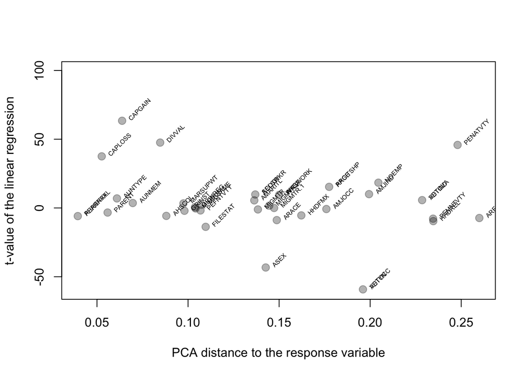

```r
## Get the t-values of the coefficients
TVAL.LIN <- SUM.LIN$coefficients[,3]
## Compare PCA distance and linear coefficients
PCA.VEC <- c()
TVAL.VEC <- c()
NAME.VEC <- c()
for( VAR in names(TVAL.LIN)){
  x <- DIST[which(names(DIST)==VAR)]
  y <- TVAL.LIN[which(names(TVAL.LIN)==VAR)]
  if( length(x) == 0 | length(y) == 0 ) next()
  PCA.VEC <- c( PCA.VEC,x)
  TVAL.VEC <- c( TVAL.VEC, y)
  NAME.VEC <- c( NAME.VEC, VAR )
}
 plot(PCA.VEC,TVAL.VEC,cex=2, pch=20, ylim=c(-60,100), col=rgb(0,0,0,0.3),xlab = "PCA distance to the response variable",ylab = "t-value of the linear regression")
sh=0.005
text(x=PCA.VEC+sh, y=TVAL.VEC+sh,labels=rownames(LO), adj=c(0,0), cex=0.5,srt=45)
```

```r
## Reduced sets of variables
VAR.RED <- c("CAPLOSS","CAPGAIN","DIVVAL","PEARNVAL")
LEARN.DATA.RED <- LEARN.DATA.SCALED[ , names(LEARN.DATA.SCALED) %in% VAR.RED]
## Again linear regression
PRED.LIN.RED <- lm(PEARNVAL ~ ., data = LEARN.DATA.RED)
## Print the details
SUM.LIN.RED <- summary(PRED.LIN.RED)
print(SUM.LIN.RED)
```

```
##
## Call:
## lm(formula = PEARNVAL ~ ., data = LEARN.DATA.RED)
##
## Residuals:
##      Min       1Q   Median       3Q      Max
## -2.01011 -0.04533 -0.04533 -0.04533  0.95467
##
## Coefficients:
##              Estimate Std. Error t value Pr(>|t|)
## (Intercept) 1.0453326  0.0007196 1452.73   <2e-16 ***
## CAPGAIN     1.1733312  0.0157533   74.48   <2e-16 ***
## CAPLOSS     0.5657211  0.0113908   49.66   <2e-16 ***
## DIVVAL      1.7914498  0.0369043   48.54   <2e-16 ***
## ---
## Signif. codes:  0 '***' 0.001 '**' 0.01 '*' 0.05 '.' 0.1 ' ' 1
##
## Residual standard error: 0.222 on 98430 degrees of freedom
## Multiple R-squared:  0.105,  Adjusted R-squared:  0.105
## F-statistic:  3849 on 3 and 98430 DF,  p-value: < 2.2e-16
```

It however does not look like improving the regression. We teach now a basic decision tree:

```r
## Teach the decision tree
PRED.DT <- rpart(PEARNVAL ~ ., data = LEARN.DATA.SCALED, method="anova")
## Now on the reduced datasets
PRED.DT.RED <- rpart(PEARNVAL ~ ., data = LEARN.DATA.RED, method="anova")
## Print the details
SUM.DT <- summary(PRED.DT)
```

```
## Call:
## rpart(formula = PEARNVAL ~ ., data = LEARN.DATA.SCALED, method = "anova")
##   n= 98434
##
##            CP nsplit rel error    xerror        xstd
## 1  0.10424967      0 1.0000000 1.0000068 0.011996557
## 2  0.05030576      1 0.8957503 0.8958588 0.011301263
## 3  0.02570466      2 0.8454446 0.8466080 0.010299150
## 4  0.02036392      3 0.8197399 0.8213966 0.010043873
## 5  0.01929662      4 0.7993760 0.7970016 0.009410066
## 6  0.01838654      5 0.7800794 0.7816993 0.009252870
## 7  0.01517647      6 0.7616928 0.7644638 0.008928159
## 8  0.01278987      7 0.7465164 0.7540582 0.008941783
## 9  0.01278656      8 0.7337265 0.7405360 0.008830310
## 10 0.01097066      9 0.7209399 0.7264117 0.008797674
## 11 0.01000000     10 0.7099693 0.7167002 0.008684784
##
## Variable importance
## CAPGAIN  ADTOCC  DIVVAL WKSWORK  ADTIND  AMJIND   NOEMP    ASEX ACLSWKR
##      23      14      10       9       7       7       6       6       5
##  AMJOCC  HHDREL    AAGE  HHDFMX
##       3       3       3       2
##
## Node number 1: 98434 observations,    complexity param=0.1042497
##   mean=1.058466, MSE=0.05504735
##   left son=2 (96881 obs) right son=3 (1553 obs)
##   Primary splits:
##       CAPGAIN < 0.07055571   to the left,  improve=0.10424970, (0 missing)
##       DIVVAL  < 6.500065e-05 to the left,  improve=0.07244660, (0 missing)
##       WKSWORK < 0.9134615    to the left,  improve=0.06740477, (0 missing)
##       HHDFMX  < 0.01351351   to the right, improve=0.04811766, (0 missing)
##       NOEMP   < 0.08333333   to the left,  improve=0.04691527, (0 missing)
##
## Node number 2: 96881 observations,    complexity param=0.05030576
##   mean=1.048874, MSE=0.04648569
##   left son=4 (87211 obs) right son=5 (9670 obs)
##   Primary splits:
##       DIVVAL  < 5.00005e-06  to the left,  improve=0.06052592, (0 missing)
##       WKSWORK < 0.9134615    to the left,  improve=0.05747948, (0 missing)
##       CAPLOSS < 0.431933     to the left,  improve=0.04276792, (0 missing)
```

[output cut: 148 more lines]

```
##       HHDREL  < 0.5          to the right, agree=0.751, adj=0.037, (0 split)
##       GRINST  < 0.45         to the right, agree=0.744, adj=0.011, (0 split)
##       GRINREG < 0.1          to the left,  agree=0.744, adj=0.010, (0 split)
##
## Node number 46: 1420 observations
##   mean=1.229577, MSE=0.1768717
##
## Node number 47: 2095 observations
##   mean=1.541289, MSE=0.2482952
##
## Node number 78: 1443 observations
##   mean=1.059598, MSE=0.05604613
##
## Node number 79: 4138 observations
##   mean=1.295312, MSE=0.2081027
```

```r
print(SUM.DT)
```

```
## n= 98434
##
## node), split, n, deviance, yval
##       * denotes terminal node
##
##  1) root 98434 5418.53100 1.058466
##    2) CAPGAIN< 0.07055571 96881 4503.58000 1.048874
##      4) DIVVAL< 5.00005e-06 87211 2637.04200 1.031212
##        8) WKSWORK< 0.9134615 57117  306.33910 1.005392 *
##        9) WKSWORK>=0.9134615 30094 2220.36000 1.080215
##         18) ADTOCC>=0.4021739 19169  679.07140 1.036778 *
##         19) ADTOCC< 0.4021739 10925 1441.66100 1.156430
##           38) ASEX>=0.5 5344  370.91000 1.075037 *
##           39) ASEX< 0.5 5581 1001.44800 1.234367
##             78) AAGE< 0.35 1443   80.87457 1.059598 *
##             79) AAGE>=0.35 4138  861.12900 1.295312 *
##      5) DIVVAL>=5.00005e-06 9670 1593.95500 1.208170
##       10) WKSWORK< 0.9134615 4010  245.75090 1.065586 *
##       11) WKSWORK>=0.9134615 5660 1208.92200 1.309187
##         22) ADTOCC>=0.4021739 2145  250.79250 1.135198 *
##         23) ADTOCC< 0.4021739 3515  853.57040 1.415363
##           46) ASEX>=0.5 1420  251.15770 1.229577 *
##           47) ASEX< 0.5 2095  520.17850 1.541289 *
##    3) CAPGAIN>=0.07055571 1553  350.07080 1.656793
##      6) CAPGAIN< 0.100411 707  172.85150 1.425743 *
##      7) CAPGAIN>=0.100411 846  107.93500 1.849882 *
```

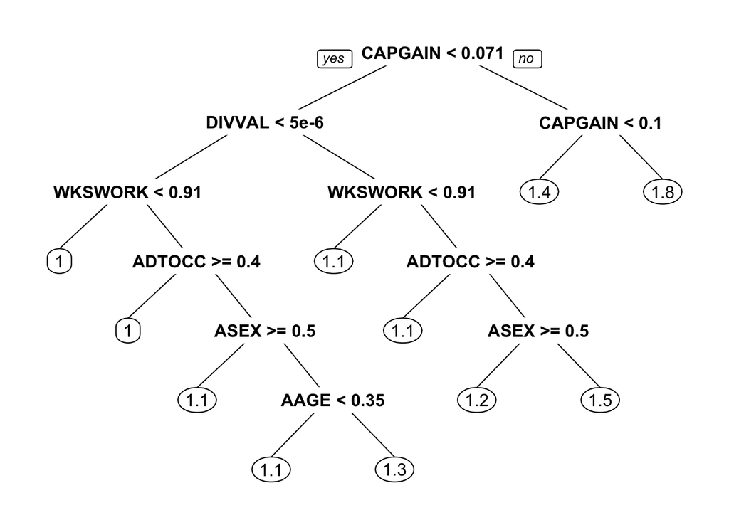

```r
## Plot the tree
prp(PRED.DT)
```

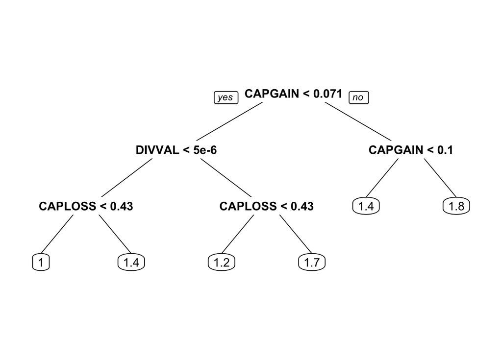

```r
prp(PRED.DT.RED)
```

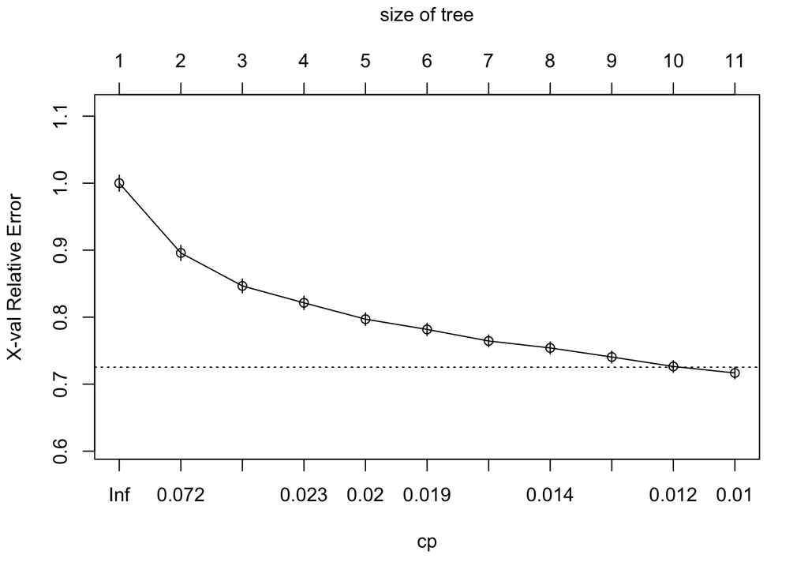

```r
## Plot the tree performance
plotcp(PRED.DT)
```

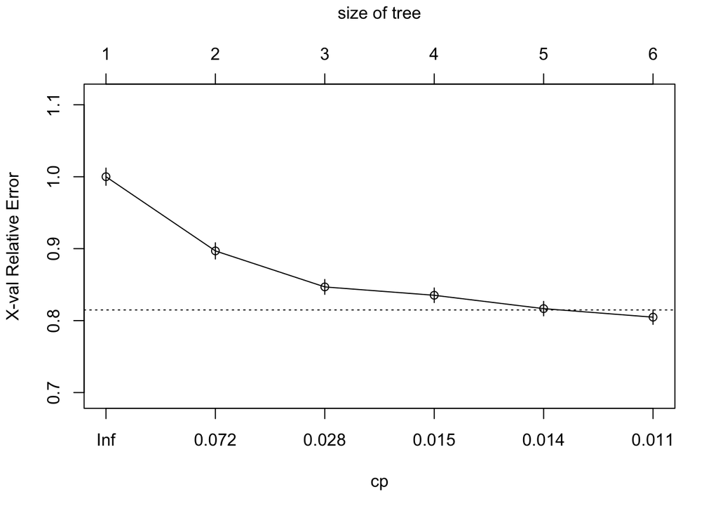

```r
plotcp(PRED.DT.RED)
```

and a basic neural network with intermediate layers, plotting a full network with dozens of variables is cumbersome, hence we plot here only the reduced version:

```r
## Run a neural network on the full dataset
PRED.NN = nnet( PEARNVAL ~ ., data = LEARN.DATA.SCALED, size = 3, linout=TRUE, skip=TRUE, MaxNWts=1000, trace=FALSE, maxit=100)
## Run on the reduced dataset
PRED.NN.RED = nnet( PEARNVAL ~ ., data = LEARN.DATA.RED, size = 3, maxit=100)
```

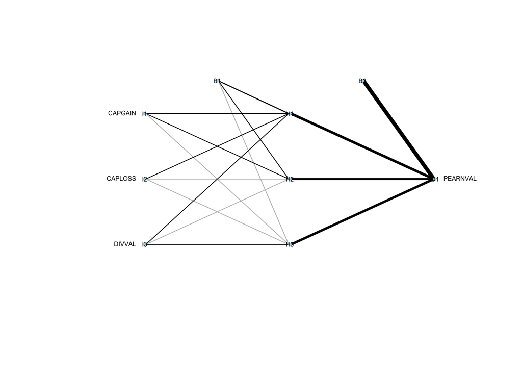

```r
## Plot the reduced neural network
plot.nnet(PRED.NN.RED,circle.cex = 0.5,cex.val = 0.5)
```

## Estimation of the performance

We want now to estimate the performance of these prediction tools, and for that purpose will use a shuffled dataset of size 1000:

```r
## Create a shuffled dataset of 1000 entries
LEARN.DATA.SHUF <- LEARN.DATA.SCALED[sample(nrow(LEARN.DATA.SCALED),size=1000),]
## Predict the value of the response variable
PRED.LIN.SHUF <- predict( PRED.LIN, LEARN.DATA.SHUF )
PRED.NN.SHUF <- predict( PRED.NN, LEARN.DATA.SHUF )
PRED.DT.SHUF <- predict( PRED.DT, LEARN.DATA.SHUF )
PRED.LIN.RED.SHUF <- predict( PRED.LIN.RED, LEARN.DATA.SHUF )
PRED.NN.RED.SHUF <- predict( PRED.NN.RED, LEARN.DATA.SHUF )
PRED.DT.RED.SHUF <- predict( PRED.DT.RED, LEARN.DATA.SHUF )
## Paste these predictions
LEARN.DATA.SHUF$pred.lin <- PRED.LIN.SHUF
LEARN.DATA.SHUF$pred.nn <- PRED.NN.SHUF
LEARN.DATA.SHUF$pred.dt <- PRED.DT.SHUF
LEARN.DATA.SHUF$pred.lin.red <- PRED.LIN.RED.SHUF
LEARN.DATA.SHUF$pred.nn.red <- PRED.NN.RED.SHUF
LEARN.DATA.SHUF$pred.dt.red <- PRED.DT.RED.SHUF
## Plot the ROC for each method
plot(roc(LEARN.DATA.SHUF$PEARNVAL,LEARN.DATA.SHUF$pred.lin), col="red")
```

```
##
## Call:
## roc.default(response = LEARN.DATA.SHUF$PEARNVAL, predictor = LEARN.DATA.SHUF$pred.lin)
##
## Data: LEARN.DATA.SHUF$pred.lin in 950 controls (LEARN.DATA.SHUF$PEARNVAL 1) < 50 cases (LEARN.DATA.SHUF$PEARNVAL 2).
## Area under the curve: 0.9005
```

```r
plot(roc(LEARN.DATA.SHUF$PEARNVAL,LEARN.DATA.SHUF$pred.nn), col="blue", add=TRUE)
```

```
##
## Call:
## roc.default(response = LEARN.DATA.SHUF$PEARNVAL, predictor = LEARN.DATA.SHUF$pred.nn)
##
## Data: LEARN.DATA.SHUF$pred.nn in 950 controls (LEARN.DATA.SHUF$PEARNVAL 1) < 50 cases (LEARN.DATA.SHUF$PEARNVAL 2).
## Area under the curve: 0.8856
```

```r
plot(roc(LEARN.DATA.SHUF$PEARNVAL,LEARN.DATA.SHUF$pred.dt), col="green", add=TRUE)
```

```
##
## Call:
## roc.default(response = LEARN.DATA.SHUF$PEARNVAL, predictor = LEARN.DATA.SHUF$pred.dt)
##
## Data: LEARN.DATA.SHUF$pred.dt in 950 controls (LEARN.DATA.SHUF$PEARNVAL 1) < 50 cases (LEARN.DATA.SHUF$PEARNVAL 2).
## Area under the curve: 0.8661
```

```r
## Reduced dataset
plot(roc(LEARN.DATA.SHUF$PEARNVAL,LEARN.DATA.SHUF$pred.lin.red), lty="dotted", col="red", add=TRUE)
```

```
##
## Call:
## roc.default(response = LEARN.DATA.SHUF$PEARNVAL, predictor = LEARN.DATA.SHUF$pred.lin.red)
##
## Data: LEARN.DATA.SHUF$pred.lin.red in 950 controls (LEARN.DATA.SHUF$PEARNVAL 1) < 50 cases (LEARN.DATA.SHUF$PEARNVAL 2).
## Area under the curve: 0.7304
```

```r
plot(roc(LEARN.DATA.SHUF$PEARNVAL,LEARN.DATA.SHUF$pred.nn.red), col="blue", lty="dotted", add=TRUE)
```

```
##
## Call:
## roc.default(response = LEARN.DATA.SHUF$PEARNVAL, predictor = LEARN.DATA.SHUF$pred.nn.red)
##
## Data: LEARN.DATA.SHUF$pred.nn.red in 950 controls (LEARN.DATA.SHUF$PEARNVAL 1) < 50 cases (LEARN.DATA.SHUF$PEARNVAL 2).
## Area under the curve: 0.5
```

```r
plot(roc(LEARN.DATA.SHUF$PEARNVAL,LEARN.DATA.SHUF$pred.dt.red), col="green", lty="dotted", add=TRUE)
```

```
##
## Call:
## roc.default(response = LEARN.DATA.SHUF$PEARNVAL, predictor = LEARN.DATA.SHUF$pred.dt.red)
##
## Data: LEARN.DATA.SHUF$pred.dt.red in 950 controls (LEARN.DATA.SHUF$PEARNVAL 1) < 50 cases (LEARN.DATA.SHUF$PEARNVAL 2).
## Area under the curve: 0.7418
```

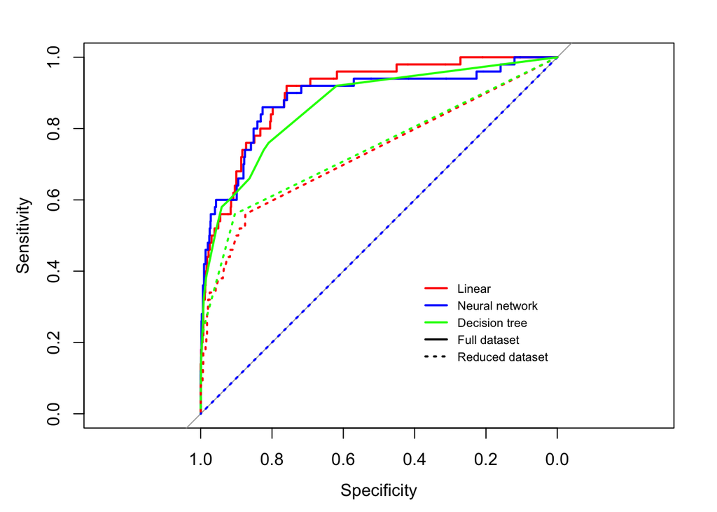

```r
## Legend
legend(x=0.4,y=0.4,col = c("red","blue","green","black","black"),legend = c("Linear","Neural network","Decision tree","Full dataset","Reduced dataset"), cex=0.7,lty=c(1,1,1,1,3), lwd=2,bty="n")
```

From these ROC, it looks like all methods perform in an equivalent way, the reduced dataset showing clearly lower performances. Simpler is better, I would hence choose the linear method. Given these ROC, we can get a cutoff based on a simple cost function that optimises sensitivity and specificity:

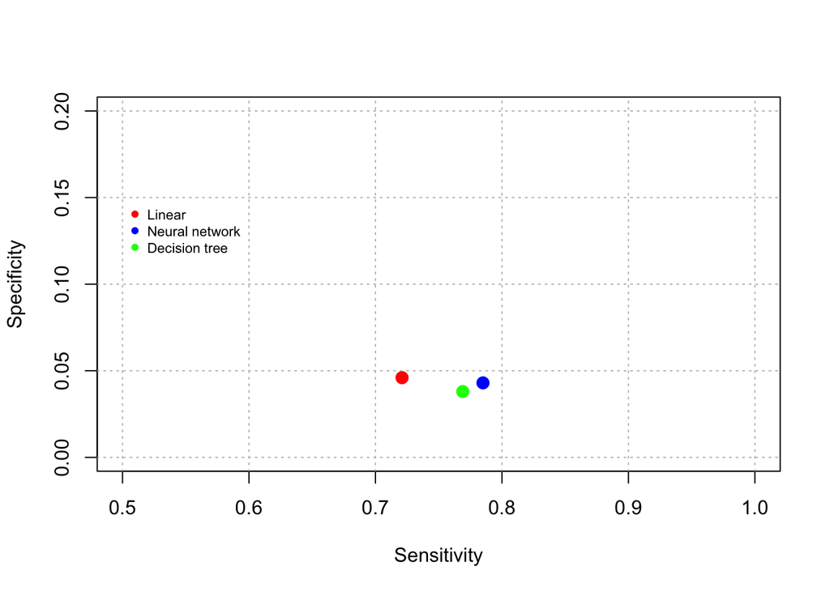

```r
## Getting the ROC
ROC.LIN.SHUF <- roc(LEARN.DATA.SHUF$PEARNVAL,LEARN.DATA.SHUF$pred.lin)
ROC.NN.SHUF <- roc(LEARN.DATA.SHUF$PEARNVAL,LEARN.DATA.SHUF$pred.nn)
ROC.DT.SHUF <- roc(LEARN.DATA.SHUF$PEARNVAL,LEARN.DATA.SHUF$pred.dt)
## Cut off on each prediction
CUT.LIN <- coords(ROC.LIN.SHUF, "best", ret = "threshold")
CUT.NN <- coords(ROC.NN.SHUF, "best", ret = "threshold")
CUT.DT <- coords(ROC.DT.SHUF, "best", ret = "threshold")
## Sensitivity and specificity
N <- 1000
SENS.LIN <- nrow(subset(LEARN.DATA.SHUF, pred.lin < CUT.LIN & PEARNVAL == 1 )) / N
SPE.LIN <- nrow(subset(LEARN.DATA.SHUF, pred.lin >= CUT.LIN & PEARNVAL == 2 )) / N
SENS.NN <- nrow(subset(LEARN.DATA.SHUF, pred.nn < CUT.NN & PEARNVAL == 1 )) / N
SPE.NN <- nrow(subset(LEARN.DATA.SHUF, pred.nn >= CUT.NN & PEARNVAL == 2 )) / N
SENS.DT <- nrow(subset(LEARN.DATA.SHUF, pred.dt < CUT.DT & PEARNVAL == 1 )) / N
SPE.DT <- nrow(subset(LEARN.DATA.SHUF, pred.dt >= CUT.DT & PEARNVAL == 2 )) / N
## Plot these values
plot( 0, xlab="Sensitivity",ylab="Specificity",xlim=c(0.5,1),ylim=c(0,0.2),col="white")
grid(col = "gray",lty = "dotted")
points(SENS.LIN, SPE.LIN,col="red",pch=20, cex=2)
points(SENS.NN, SPE.NN,col="blue",pch=20, cex=2)
points(SENS.DT, SPE.DT,col="green",pch=20, cex=2)
legend(x=0.5,y=0.15,col = c("red","blue","green"),legend = c("Linear","Neural network","Decision tree"), cex=0.7,pt.cex=1,pch=20, bty="n")
```

## Study of the test sample with the predictive methods

The test sample is now unblinded, let’s open the test dataset file:

```r
## Path to the test dataset
TEST.DATA <- "us_census_full/census_income_test.csv"
## Replace question marks by NA, and remove white spaces
system(paste("sed s/\'?\'/'NA'/g",TEST.DATA,"> foo; mv foo", TEST.DATA))
system(paste("sed s/\' \'//g",TEST.DATA,"> foo; mv foo", TEST.DATA))
## Open the learning dataset
TEST.DATA <- read.csv(TEST.DATA, stringsAsFactors=FALSE)
## Extracting the names of the columns
colnames(TEST.DATA) <- unlist(HEADER)
## The testing set needs to be scaled as well
## Remove uncorrelated variables
 TEST.DATA.REM <- TEST.DATA[ , !(names(TEST.DATA) %in% VAR.REM)]
## Remove all NA
 TEST.DATA.SCALED <- na.omit(TEST.DATA.REM)
 ## Replace the categorical variables
## Loop over all variables
for( icol in 1:ncol(TEST.DATA.SCALED) ){
  ## Consider categorical variables
if( class(TEST.DATA.SCALED[,icol]) != "character" ) next()
## List the unique values
    COL.DAT <- TEST.DATA.SCALED[,icol]
 UNIQ.VAL <- unique(COL.DAT)
  NB.UNIQ.VAL <- length(UNIQ.VAL)
  ## Replace their values by an integer
 for( ival in 1:NB.UNIQ.VAL){
   COL.DAT[COL.DAT==UNIQ.VAL[ival]] = ival
    TEST.DATA.SCALED[,icol] <- as.numeric(COL.DAT)
 }
}
 ## Some variables are then constant, let's remove them
TEST.DATA.SCALED <- TEST.DATA.SCALED[,apply(TEST.DATA.SCALED, 2, var, na.rm=TRUE) != 0]
## Loop over all variables
for( icol in 1:ncol(TEST.DATA.SCALED) ){
  ## Keep the response raw
    if( colnames(TEST.DATA.SCALED)[icol] == "PEARNVAL") next()
  ## Scale the predictor variables by doing X = (X - max(X) / (max(X)-min(X))
  MIN <- min(TEST.DATA.SCALED[,icol])
  MAX <- max(TEST.DATA.SCALED[,icol])
   TEST.DATA.SCALED[,icol] <- (TEST.DATA.SCALED[,icol] - MIN) / ( MAX - MIN )
}
```

and run the predictive methods on it:

```r
## Prediction
PRED.LIN.TEST <- predict( PRED.LIN, TEST.DATA.SCALED )
PRED.NN.TEST <- predict( PRED.NN, TEST.DATA.SCALED )
PRED.DT.TEST <- predict( PRED.DT, TEST.DATA.SCALED )
## Add the prediction to the dataset
TEST.DATA.SCALED$pred.lin <- PRED.LIN.TEST
TEST.DATA.SCALED$pred.nn <- PRED.NN.TEST
TEST.DATA.SCALED$pred.dt <- PRED.DT.TEST
```

Now let’s apply the cut-off determined in the learning set and check the sensitivity and specificity:

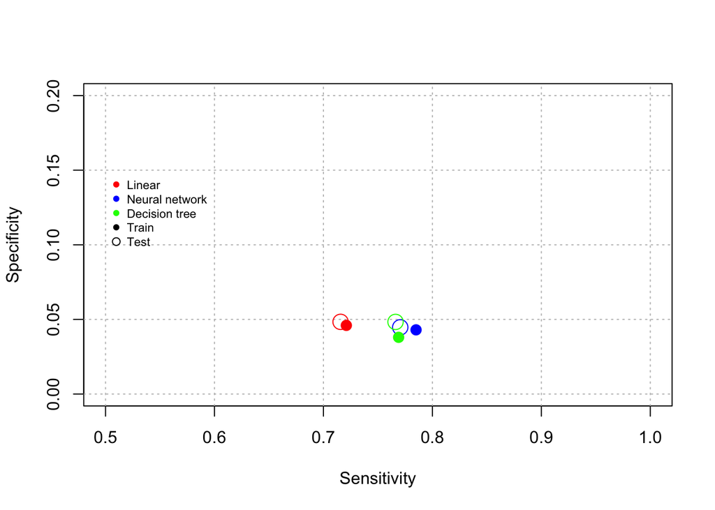

```r
N <- nrow(TEST.DATA.SCALED)
SENS.LIN.TEST <- nrow(subset(TEST.DATA.SCALED, pred.lin < CUT.LIN & PEARNVAL == 1 )) / N
SPE.LIN.TEST <- nrow(subset(TEST.DATA.SCALED, pred.lin >= CUT.LIN & PEARNVAL == 2 )) / N
SENS.NN.TEST <- nrow(subset(TEST.DATA.SCALED, pred.nn < CUT.NN & PEARNVAL == 1 )) / N
SPE.NN.TEST <- nrow(subset(TEST.DATA.SCALED, pred.nn >= CUT.NN & PEARNVAL == 2 )) / N
SENS.DT.TEST <- nrow(subset(TEST.DATA.SCALED, pred.dt < CUT.DT & PEARNVAL == 1 )) / N
SPE.DT.TEST <- nrow(subset(TEST.DATA.SCALED, pred.dt >= CUT.DT & PEARNVAL == 2 )) / N
## Plot these values
plot( 0, xlab="Sensitivity",ylab="Specificity",xlim=c(0.5,1),ylim=c(0,0.2),col="white")
grid(col = "gray",lty = "dotted")
points(SENS.LIN.TEST, SPE.LIN.TEST,col="red",pch=1, cex=2)
points(SENS.NN.TEST, SPE.NN.TEST,col="blue",pch=1, cex=2)
points(SENS.DT.TEST, SPE.DT.TEST,col="green",pch=1, cex=2)
points(SENS.LIN, SPE.LIN,col="red",pch=20, cex=2)
points(SENS.NN, SPE.NN,col="blue",pch=20, cex=2)
points(SENS.DT, SPE.DT,col="green",pch=20, cex=2)
legend(x=0.5,y=0.15,col = c("red","blue","green","black","black"),legend = c("Linear","Neural network","Decision tree","Train","Test"), cex=0.7,pt.cex=1,pch=c(20,20,20,20,1), bty="n")
```

The performances are similar with the testing dataset, which ensures a reliable training of the predictive tools. I would however recommand further analysis with more shuffled dataset and the training of independant subsets. The decision tree seems not to have suffered of any over-training, which is a sign of reliable training given the high sensitivity of this tool to over-training.